# Show B0 and B1 are unbiased

```r
library(tidyverse)
```

### Perform some simulations to empirically show that beta0 and beta1 are unbiased. In particular, do the following:

#### (i) Randomly sample 75 values of X from N(10, 12).

#### (ii) Randomly sample 75 values of Y from N(15 + 2X, 42). (Note: If you plug in your vector X of 75 values into rnorm with n=75, that will sample a corresponding Y to go with each of the X values).

#### (iii) Run a regression of Y over X and save the values of beta0 and beta1.

#### (iv) Repeat this 10000 times.

```r
beta0 <- NULL
beta1 <- NULL

for(i in 1:10000){
  x_vals <- rnorm(75, mean=10, sd=1)
  y_vals <- rnorm(75, mean=(15+2*x_vals), 4)

  data_frame <- data.frame(x_vals, y_vals)

  model <- lm(y_vals ~ x_vals, data = data_frame)
  bt0 <- model[["coefficients"]][["(Intercept)"]]
  bt1 <- model[["coefficients"]][["x_vals"]]

  beta0 <- c(beta0, bt0)
  beta1 <- c(beta1, bt1)
}
```

#### (v) Calculate the mean of all the beta0 and beta1 values.

```r
  beta0_mean <- mean(beta0)
  beta1_mean <- mean(beta1)
```

```r
  beta0_mean
```

```
## [1] 15.01344
```

```r
  beta1_mean
```

```
## [1] 1.998524
```

#### (vi) Compare the empirical means from part v to the true values of beta0 and beta1.

They are relatively the same. We obtained Y randomly from a distribution N(15 + 2X, 42). As such, we expected the y-intercept to be 15 on average and beta1 to be 2 on average. Here, we got that are almost exactly similar to what we expected as is evident above.With a larger sample, these values are expected to be closer to 15 and 2, respectively

##### Beta0

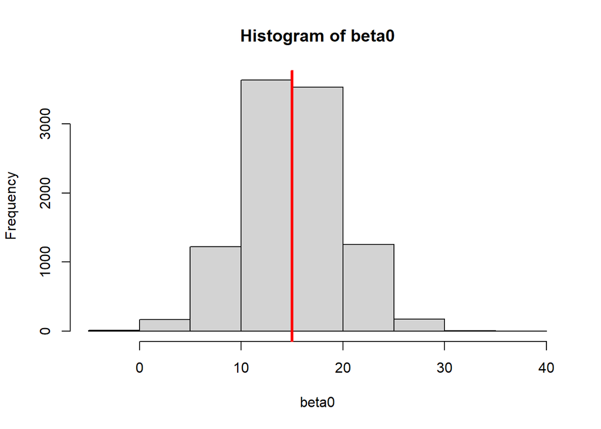

```r
 hist(beta0)
abline(v=15, col='red', lwd=3,)
```

##### Beta1

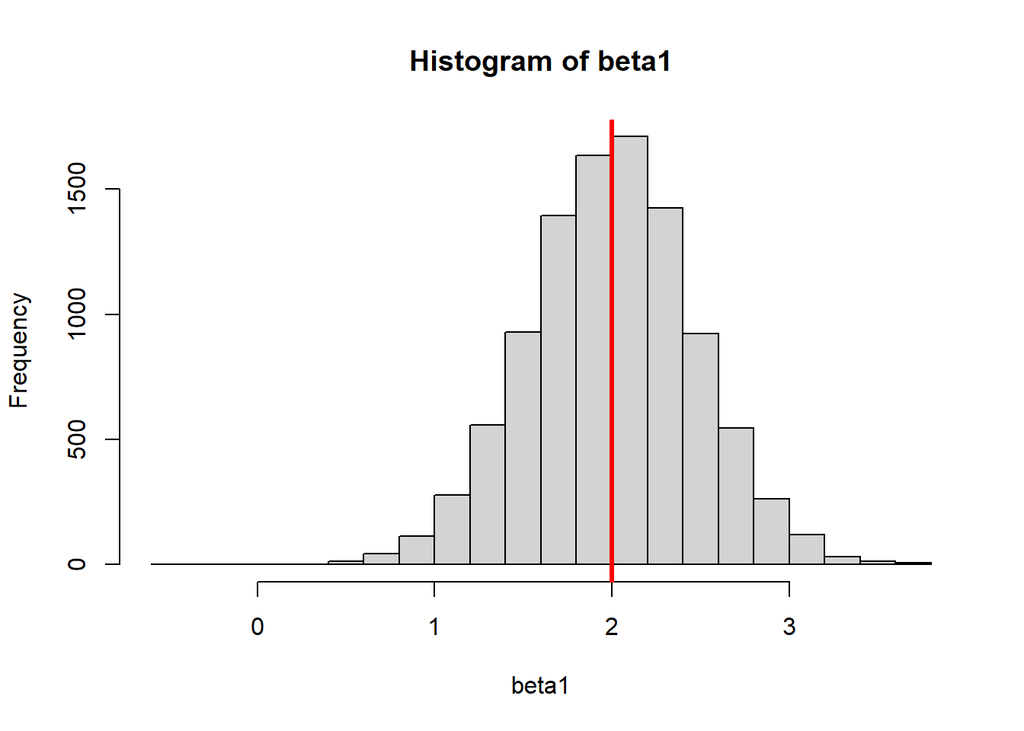

```r
hist(beta1)
abline(v=2, col='red', lwd=3,)
```